# ESM 201 Assignment 2

Sidney Gerst

March 15, 2019

### 1. Patters in yield over time

1. plot of yield vs time for each grain

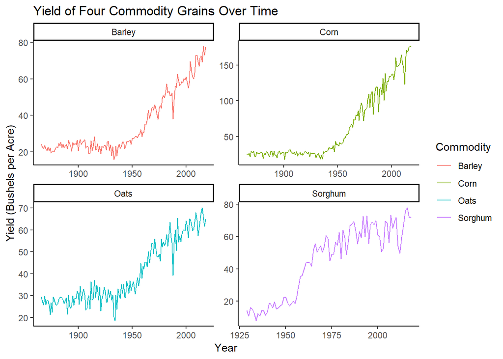

**Figure 1.** The yield of four commodity grains grown in the United States in bushels per acre from 1866-2018 (Barley, Corn, and Oats) and 1925-2018 (Sorghum).

2. Describe the statistical trend for each grain
- Barley: There is a fairly flat linear lower plateau that increases drastically in the 1950’s that shows an exponential trend.
- Corn: There is a relatively flat linear lower plateau that increases dramatically in the 1950’s that represents an exopoential trend.
- Oats: The curve for Oats looks like the very early stages of the exponential curve. It’s not very steep and there is a bit of variation between 1866 and 1950 before it shoots off.

Sorghum: The sorghum curve is a logistic trend because the beginning of this curve is low around 1925 and increases in the 1950’s and levels off at the 1970’s.